# Zabalo Report

Morgan Manning

8/15/2023

# Introduction

Mammal population dynamics are closely linked to human activity (Lee 1987, Ritzel and Gallo 2020). This tie of human culture to the environment is known as “biocultural heritage” (Davidson-Hunt et al. 2012, Gavin et al. 2015). Biocultural heritage includes the practices and knowledge of indigenous communities and positively affects local wildlife populations. Many of these indigenous communities have faced a loss of biocultural heritage (Davidson-Hunt et al. 2012, Gavin et al. 2015, Rotherham 2015). With this loss of biocultural heritage, indigenous communities interact less directly with the environment, but interactions tend to be more extractive than in communities with a stronger link to biocultural heritage (Peres 2001, Gavin et al. 2015, Rotherham 2015, de Araujo Lima Constantino 2016). One such example of this is hunting. Indigenous communities with strong ties to their biocultural heritage rely on daily subsistence hunting whereas communities with detachment from biocultural heritage rely on daily or weekly markets for food. Studies have shown that hunting increases with a community’s access to a market, where individuals are able to sell excess meat (de la Montaña et al. 2015, de Araujo Lima Constantino 2016). Conversely, communities that rely on subsistence hunting have lower harvest rates. This preliminary report will focus on Zabalo, one of the four indigenous communities in the Ecuadorian Amazon that will be included in our research on mammal occupancy across the gradient of detachment from biocultural heritage. Zabalo represents the community with the strongest ties to the environment, with members relying on daily subsistence hunting.

# Methodology

$$Hunting\ Intensity_j = \sum_{i = 1}^{777}{e^{-(distance_{ij})}}$$
where $distance_{ij}$ is the distance between hunting occasion *i* and camera trap site *j*.

All continuous covariates were normalized. All combinations of occupancy and detection covariates (n = 512) were modeled for each species using the *unmarked* package with the number of iterations increased to 10,000 and providing a starting value of 0 for all parameters (Fiske and Chandler 2011). Models with convergence problems and with standard errors larger than the absolute value of the intercept estimate were removed.

# Results

## Collared peccary

### Best Model (based on AIC)

```
##
## Call:
## occu(formula = formula(unmarkedModels[1, 1]), data = peccaryUFO,
##     starts = c(rep(0, length(test@opt$par))), control = 10000)
##
## Occupancy:
##                  Estimate    SE     z P(>|z|)
## (Intercept)          2.05  1.92 1.070  0.2846
## Community            7.01  3.42 2.048  0.0405
## HabitatSwamp         8.72 70.19 0.124  0.9011
## HabitatUpland        2.59  2.15 1.209  0.2265
## HuntingIntensity     5.17  2.90 1.781  0.0748
##
## Detection:
##  Estimate    SE       z P(>|z|)
##   -0.0183 0.226 -0.0811   0.935
##
## AIC: 138.2431
```

### Top Models (all models within 2 of the lowest AIC)

```
##                                               formula      AIC      AICwt
## 104       ~1 ~ Community + Habitat + HuntingIntensity 138.2431 0.06372230
## 105           ~1 ~ River + Hunting + HuntingIntensity 138.3045 0.06179774
## 78   ~Effort ~ Community + Habitat + HuntingIntensity 138.8618 0.04676803
## 91                                     ~1 ~ Community 139.3395 0.03683093
## 92                                         ~1 ~ River 139.7046 0.03068589
## 84                                        ~Effort ~ 1 139.7247 0.03037945
## 8                                     ~Effort ~ River 140.0656 0.02561843
## 79  ~OnTrail ~ Community + Habitat + HuntingIntensity 140.2249 0.02365660
## 94                                ~1 ~ Trail.Distance 140.2293 0.02360439
## 1                                 ~Effort ~ Community 140.2343 0.02354558
```

### Prediction Plots

Occupancy probability is plotted across each normalized covariate by holding all other continuous covariates at their means or at the mode for factor covariates. All models (after the removal of models with convergence issues and with standard errors larger than the intercept estimate) were weighted and averaged to predict occupancy.

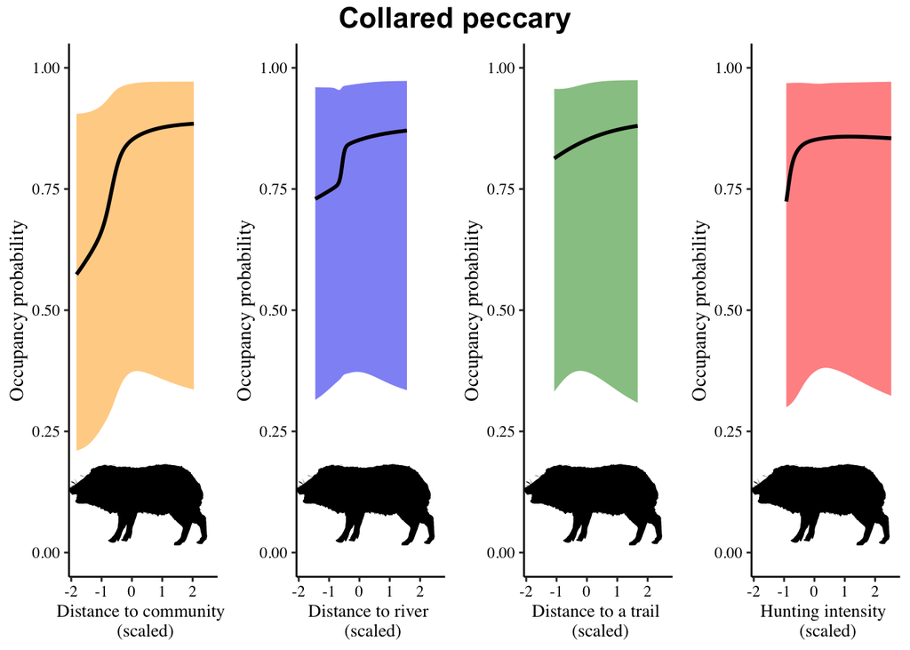

## Lowland paca

### Best Model (based on AIC)

```
##
## Call:
## occu(formula = formula(unmarkedModels[1, 1]), data = pacaUFO,
##     starts = c(rep(0, length(test@opt$par))), control = 10000)
##
## Occupancy:
##                Estimate   SE    z P(>|z|)
## (Intercept)        3.45 2.28 1.52   0.129
## Trail.Distance     2.79 2.43 1.15   0.250
##
## Detection:
##               Estimate    SE     z  P(>|z|)
## (Intercept)     -2.792 0.307 -9.08 1.07e-19
## Effort           0.724 0.194  3.74 1.88e-04
## HabitatSwamp     0.881 0.435  2.02 4.30e-02
## HabitatUpland   -0.484 0.349 -1.39 1.65e-01
##
## AIC: 448.8441
```

### Top Models (all models within 2 of the lowest AIC)

```
##                                            formula      AIC      AICwt
## 19              ~Effort + Habitat ~ Trail.Distance 448.8441 0.13484757
## 133                          ~Effort + Habitat ~ 1 448.9915 0.12526448
## 7                        ~Effort + Habitat ~ River 449.3817 0.10306246
## 53      ~Effort + Habitat ~ River + Trail.Distance 449.9620 0.07710434
## 25            ~Effort + Habitat ~ HuntingIntensity 450.3556 0.06333173
## 37  ~Effort + Habitat ~ Community + Trail.Distance 450.5419 0.05769887
## 21    ~Effort + Habitat + OnTrail ~ Trail.Distance 450.5802 0.05660438
```

### Prediction Plots

Occupancy probability is plotted across each normalized covariate by holding all other continuous covariates at their means or at the mode for factor covariates. All models (after the removal of models with convergence issues and with standard errors larger than the intercept estimate) were weighted and averaged to predict occupancy.

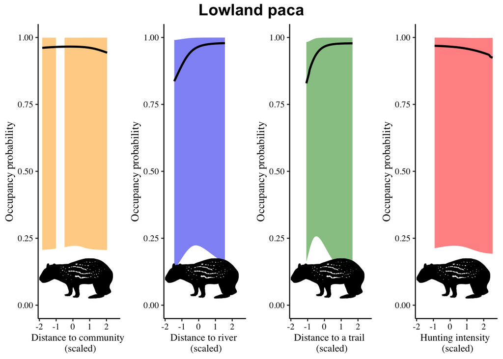

### Best Model (based on AIC)

```
##
## Call:
## occu(formula = formula(unmarkedModels[1, 1]), data = brocketUFO,
##     starts = c(rep(0, length(test@opt$par))), control = 10000)
##
## Occupancy:
##             Estimate    SE    z P(>|z|)
## (Intercept)     1.32 0.785 1.68  0.0939
## Community       1.37 0.729 1.88  0.0607
##
## Detection:
##               Estimate     SE      z P(>|z|)
## (Intercept)     -0.654  0.744 -0.880  0.3789
## Effort           1.472  0.697  2.113  0.0346
## HabitatSwamp    -9.630 86.032 -0.112  0.9109
## HabitatUpland    2.278  1.102  2.068  0.0387
##
## AIC: 59.75012
```

### Top Models (all models within 2 of the lowest AIC)

```
##                                             formula      AIC      AICwt
## 3                     ~Effort + Habitat ~ Community 59.75012 0.08973342
## 26             ~Effort + Habitat ~ HuntingIntensity 60.66434 0.05681120
## 6                                  ~Habitat ~ River 61.03108 0.04729289
## 32            ~Effort + Habitat ~ Community + River 61.41579 0.03901737
## 48     ~Effort + Habitat ~ River + HuntingIntensity 61.51054 0.03721198
## 9               ~Effort + Habitat + OnTrail ~ River 61.51536 0.03712251
## 41 ~Effort + Habitat ~ Community + HuntingIntensity 61.63705 0.03493102
## 5           ~Effort + Habitat + OnTrail ~ Community 61.74056 0.03316926
```

### Prediction Plots

Occupancy probability is plotted across each normalized covariate by holding all other continuous covariates at their means or at the mode for factor covariates. All models (after the removal of models with convergence issues and with standard errors larger than the intercept estimate) were weighted and averaged to predict occupancy.

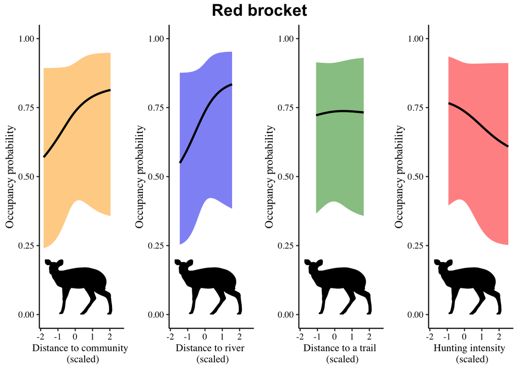

## Bibliography

1. de Araujo Lima Constantino, P. 2016. Deforestation and hunting effects on wildlife across Amazonian indigenous lands. Ecology and Society 21. https://www.jstor.org/stable/26270361. Accessed 15 Apr 2023.
2. Davidson-Hunt, I. J., K. L. Turner, A. T. P. Mead, J. Cabrera-Lopez, R. Bolton, C. J. Idrobo, I. Miretski, A. Morrison, and J. P. Robson. 2012. Biocultural Design: A New Conceptual Framework for Sustainable Development in Rural Indigenous and Local Communities. S.A.P.I.EN.S. Surveys and Perspectives Integrating Environment and Society. https://journals.openedition.org/sapiens/1382. Accessed 3 Aug 2023.
3. Fiske, I., and R. Chandler. 2011. unmarked: An R Package for Fitting Hierarchical Models of Wildlife Occurrence and Abundance. Journal of Statistical Software 43:1–23.
4. Gavin, M. C., J. McCarter, A. Mead, F. Berkes, J. R. Stepp, D. Peterson, and R. Tang. 2015. Defining biocultural approaches to conservation. Trends in Ecology & Evolution 30:140–145.
5. Lee, R. D. 1987. Population Dynamics of Humans and Other Animals. Demography 24:443–465.
6. de la Montaña, E., R. del Pilar Moreno-Sánchez, J. H. Maldonado, and D. M. Griffith. 2015. Predicting hunter behavior of indigenous communities in the Ecuadorian Amazon: insights from a household production model. Ecology and Society 20. https://www.jstor.org/stable/26270294. Accessed 15 Apr 2023.
7. Peres, C. A. 2001. Synergistic Effects of Subsistence Hunting and Habitat Fragmentation on Amazonian Forest Vertebrates. Conservation Biology 15:1490–1505.
8. Ritzel, K., and T. Gallo. 2020. Behavior Change in Urban Mammals: A Systematic Review. Frontiers in Ecology and Evolution 8. https://www.frontiersin.org/articles/10.3389/fevo.2020.576665. Accessed 3 Aug 2023.
9. Rotherham, I. D. 2015. Bio-cultural heritage and biodiversity: emerging paradigms in conservation and planning. Biodiversity and Conservation 24:3405–3429.